# Other methods

Karla Monterrubio-Gómez, Nathan Constantine-Cooke, and Catalina Vallejos

2022-11-16

# Dataset

In order to demonstrate the methods, we employ publicly available data.

The dataset used here corresponds to the Hodgkin’s disease (HD) study described in Pintilie (2006). The dataset comprises 865 patients diagnosed with early stage (I or II) HD, and which were treated either with radiation (RT) or with radiation and chemotherapy (CMT).

The recorded data includes:

- age: Age (years)
- sex: Sex, F=female and M=Male.
- trtgiven: Treatment given, RT=Radiation, CMT=Chemotherapy and radiation
- medwidsi: Size of mediastinum involvement, N=No, S=Small, L=Large
- extranod: Extranodal disease, Y=Extranodal disease, N= Nodal disease
- clinstg: Clinical stage, 1=Stage I, 2=Stage II
- time: time to failure (years) calculated from the date of diagnosis
- status: 0=censoring, 1=relapse and 2=death.

We now load and display the structure of the HD dataset:

```r
library(readr)
hd <- data.frame(read_csv("../Data/HD/hd.csv",
                          col_types = cols(X1 = col_skip())))
str(hd)
```

```
#> 'data.frame':    865 obs. of  9 variables:
#>  $ ...1    : num  1 2 3 4 5 6 7 8 9 10 ...
#>  $ age     : num  64 63 17 63 21 37 41 35 27 32 ...
#>  $ sex     : chr  "F" "M" "M" "M" ...
#>  $ trtgiven: chr  "RT" "RT" "RT" "RT" ...
#>  $ medwidsi: chr  "N" "N" "N" "N" ...
#>  $ extranod: chr  "N" "N" "N" "N" ...
#>  $ clinstg : num  1 1 2 2 2 1 2 2 2 2 ...
#>  $ time    : num  3.1 15.9 0.9 13.1 35.9 1.1 2.5 0.003 4.1 28.1 ...
#>  $ status  : num  2 2 1 2 0 1 1 1 1 0 ...
```

To proceed with the analysis, it is important to change the data type of sex, trtgiven, medwidsi, and extranod from character to factor. Similarly, we convert clinstg from numeric to factor.

```r
hd$sex      <- as.factor(hd$sex)
hd$trtgiven <- as.factor(hd$trtgiven)
hd$medwidsi <- as.factor(hd$medwidsi)
hd$extranod <- as.factor(hd$extranod)
hd$clinstg  <- as.factor(hd$clinstg)
```

Now, we explore the number of events for each event type:

```r
require(pander)
pander::pander(table(hd$status))
```

| 0 | 1 | 2 |
| --- | --- | --- |
| 439 | 291 | 135 |

Thus, we have 439 censored patients, 291 with relapse, and 135 who died. From now on, we assume that the event of interest is relapse, i.e. status=1.

In order to create a test set, we use stratified sampling to partition our dataset into 80% for train and 20% for test.

```r
library(splitstackshape)
set.seed(2022)
split_data <- stratified(hd, c("status"), 0.8, bothSets = TRUE)
hd_train   <- split_data$SAMP1[,-1]
hd_test    <- split_data$SAMP2[,-1]
```

Now, we explore the number of observations per status in both train and test set:

```r
pander::pander(table(hd_train$status))
```

| 0 | 1 | 2 |
| --- | --- | --- |
| 351 | 233 | 108 |

```r
pander::pander(table(hd_test$status))
```

| 0 | 1 | 2 |
| --- | --- | --- |
| 88 | 58 | 27 |

# Random survival forests

The authors of random survival forests provide an online vignette [here](https://www.randomforestsrc.org/articles/competing.html) (Ishwaran et al. (2021)). The method can be fitted using the `randomForestSRC` package. Below we showcase how to do that.

First, in order to fit the model, both, the train and test sets should be converted to data.frames:

```r
hd_train <- as.data.frame(hd_train)
hd_test <- as.data.frame(hd_test)
```

As RSF permits, both, a cause-specific and a CIF formulation. The user should first determine the type of analysis of interest, and pass it on the argument `splitrule` in the fitter function `rfsrc()`. When the objective is to do a cause-specific hazard analysis we must set `splitrule="logrank"` and the argument `cause` should indicate the event type of interest. In contrast, if one is interested on long term predictions, `splitrule="logrankCR"` is more appropriate, as it considers the CIF. Furthermore, a composite splitting rule is available and can be used to identify variables that are important for any cause.

Below, we fit both models:

## Generalized log-rank splitting rule (logrank)

```r
library(randomForestSRC)
rsf.lr <- rfsrc(Surv(time, status) ~ age + sex + trtgiven+ medwidsi+ extranod+clinstg,
                data = hd_train,
                ntree = 100,
                splitrule = "logrank",
                cause = c(1,0),          # to indicate that first event is of interest
                bootstrap = "by.root",
                samptype = "swr",        # sampling with replacement.
                importance = "random",   # other choices available, e.g. permute
                save.memory= TRUE,       # useful for big datasets
                seed = 100)
```

Note that if missing values are present, it is possible to impute them by setting the argument `na.action=na.impute`.

A summary of the fitted object is obtained with `print()`.

```r
print(rsf.lr)
```

```
#>                          Sample size: 692
#>                     Number of events: 233, 108
#>                      Number of trees: 100
#>            Forest terminal node size: 15
#>        Average no. of terminal nodes: 47.97
#> No. of variables tried at each split: 3
#>               Total no. of variables: 6
#>        Resampling used to grow trees: swr
#>     Resample size used to grow trees: 692
#>                             Analysis: RSF
#>                               Family: surv-CR
#>                       Splitting rule: logrank *random*
#>        Number of random split points: 10
#>    (OOB) Requested performance error: 0.43894869, 0.22820705
```

We can obtain the fitted trees; for instance, a plot of the fifth fitted tree is shown:

```r
plot(get.tree(rsf.lr, 5))
```

[interactive chart not shown]

Furthermore, we can visualize the results of the fitted model with `plot.competing.risk()`. This command shows averaged out-of-bag ensemble for: CS cumulative hazard, the CIF, and the conditional probability, stratified by event type. In the plot below, the event of interest is shown in black.

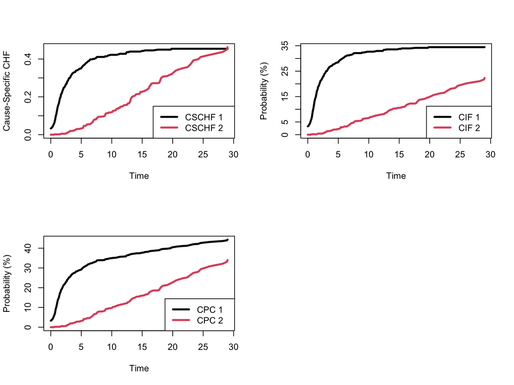

```r
plot.competing.risk(rsf.lr)
```

In addition, we can visualize marginal effects according to the expected number of years lost due to the event specific cause. Recall, that this measure is a 1-dimensional summary of the CIF.

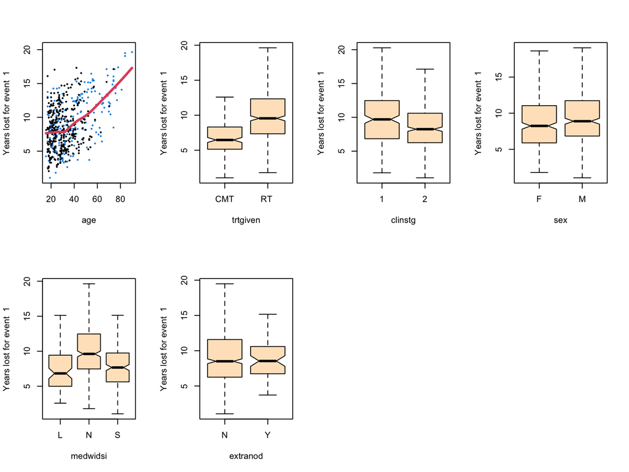

```r
plot.variable(rsf.lr, target = 1,
              surv.type = "years.lost",
              sorted = TRUE)
```

We can obtain both, in-bag and out-of-bag, estimates of the cause-specific cumulative hazard function and the CIF. Below, we show out-of-bag-estimates for the event of interest (relapse)

```r
obsv.times <- rsf.lr$time.interest  # unique event times

#out-of-bag cause-specific cumulative hazard
csh.oob <- rsf.lr$chf.oob[,,1]  # selects event type 1

#out-of-bag CIF
cif.oob <- rsf.lr$cif.oob[,,1]  # selects event type 1
```

`csh.oob` and `cif.oob` are arrays that contain in the rows estimates corresponding to the 692 subjects and in the columns the 136 unique event times.

In order to do variable selection, a variable importance measure for the event of interest is shown below. The higher the value, the better. Negative values indicate no predictive ability.

```r
rsf.lr$importance[,1]
```

```
#>          age          sex     trtgiven     medwidsi     extranod      clinstg
#>  0.020174337 -0.001455005  0.016779088 -0.001703250 -0.003966918  0.001417083
```

In addition, one can also use minimal depth variable selection. In this case, the smaller the value, the more predictive ability. The second column of the table below shows the results:

```r
var.mindepth  <- var.select(rsf.lr,
                        cause = 1,
                        method = "md", # is possible to select "vh.vimp" for variable importance measure
                        conservative = "medium" # level of conservativeness of the thresholding rule
           )
```

```
#> minimal depth variable selection ...
#>
#>
#> -----------------------------------------------------------
#> family             : surv-CR
#> var. selection     : Minimal Depth
#> conservativeness   : medium
#> x-weighting used?  : TRUE
#> dimension          : 6
#> sample size        : 692
#> ntree              : 100
#> nsplit             : 10
#> mtry               : 3
#> nodesize           : 15
#> refitted forest    : FALSE
#> model size         : 6
#> depth threshold    : 5.3022
#> PE (true OOB)      : 43.8949 22.8207
#>
#>
#> Top variables:
#>          depth vimp.event.1 vimp.event.2
#> age       0.74        0.020        0.214
#> medwidsi  1.56       -0.002        0.012
#> trtgiven  1.68        0.017       -0.006
#> extranod  2.65       -0.004       -0.008
#> clinstg   2.77        0.001       -0.006
#> sex       2.99       -0.001        0.011
#> -----------------------------------------------------------
```

```r
pander::pander(var.mindepth$varselect)
```

|  | depth | vimp.event.1 | vimp.event.2 |
| --- | --- | --- | --- |
| **age** | 0.74 | 0.02017 | 0.2135 |
| **medwidsi** | 1.56 | -0.001703 | 0.01225 |
| **trtgiven** | 1.68 | 0.01678 | -0.006373 |
| **extranod** | 2.65 | -0.003967 | -0.008177 |
| **clinstg** | 2.77 | 0.001417 | -0.006344 |
| **sex** | 2.99 | -0.001455 | 0.01074 |

In order to obtain predictions in the test set, we employ `predict()` function as shown below. A summary of the object is shown with the function `print()`

```r
test.lr <- predict(rsf.lr,
                   newdata = hd_test,
                   #VIM can also be obtained at this stage
                   importance = "random",
                   outcome = "test",
                   csv = TRUE
                   )
print(test.lr)
```

```
#>   Sample size of test (predict) data: 173
#>                 Number of grow trees: 100
#>   Average no. of grow terminal nodes: 47.97
#>          Total no. of grow variables: 6
#>        Resampling used to grow trees: swr
#>     Resample size used to grow trees: 692
#>                             Analysis: RSF
#>                               Family: surv-CR
#>          Requested performance error: 0.46889881, 0.29349398
```

The predicted CIF for patient 1 (red) and 2 (blue) in the test set is shown:

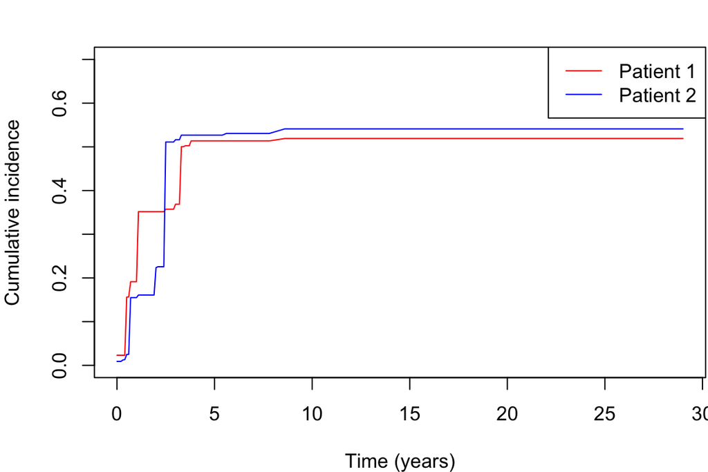

```r
CIF.hat <- test.lr$cif[,,1]  # select event of interest k=1

par(mar = c(4, 4, 2, 0.1))

plot(test.lr$time.interest,
     CIF.hat[1,],
     type = "l",
     col = "red",
     ylim = c(0, 0.7),
     xlab = "Time (years)",
     ylab = "Cumulative incidence")
lines(test.lr$time.interest,  CIF.hat[2,], col="blue")
legend("topright", legend = c("Patient 1", "Patient 2"),
       lty = c(1,1), col = c("red", "blue"))
```

The model permits to do predictions at observed unique event times. Below we show the predicted CIF for the first 5 patients in the test set at a specific time point $t=5$:

```r
test.lr$cif[1:5,obsv.times==5,1]
```

```
#> [1] 0.5135886 0.5268485 0.3649937 0.4337468 0.2491450
```

## Modified Gray’s test splitting rule (logrankCR)

```r
rsf.lrCR <- rfsrc(Surv(time, status) ~ age + sex + trtgiven+ medwidsi+ extranod+clinstg,
                data = hd_train,
                ntree = 100,
                splitrule = "logrankCR",
                cause = c(1,0),          # to indicate that first event is of interest
                bootstrap = "by.root",
                samptype = "swr",        # sampling with replacement.
                importance = "random",   # other choices available, e.g. permute
                save.memory= TRUE,       # useful for big datasets
                seed = 100
                )

print(rsf.lrCR)
```

```
#>                          Sample size: 692
#>                     Number of events: 233, 108
#>                      Number of trees: 100
#>            Forest terminal node size: 15
#>        Average no. of terminal nodes: 48.37
#> No. of variables tried at each split: 3
#>               Total no. of variables: 6
#>        Resampling used to grow trees: swr
#>     Resample size used to grow trees: 692
#>                             Analysis: RSF
#>                               Family: surv-CR
#>                       Splitting rule: logrankCR *random*
#>        Number of random split points: 10
#>    (OOB) Requested performance error: 0.44416446, 0.22447986
```

As before fitted trees can be obtained with `get.tree`.

```r
plot(get.tree(rsf.lrCR, 5))
```

[interactive chart not shown]

Similarly, one can visualize the results of the fitted model with `plot.competing.risk()`, which shows 3 plots: a CS cumulative hazard, the CIF, and the conditional probability, stratified by event type. In the plot below, the event of interest is shown in black.

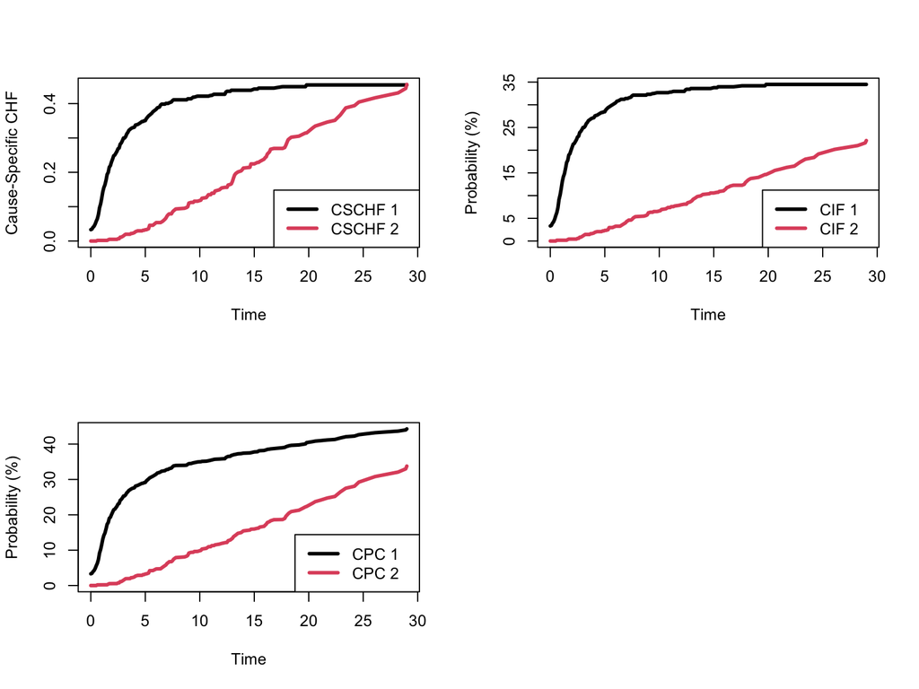

```r
plot.competing.risk(rsf.lrCR)
```

In addition, we can visualize marginal effects according to the expected number of years lost due to the event specific cause.

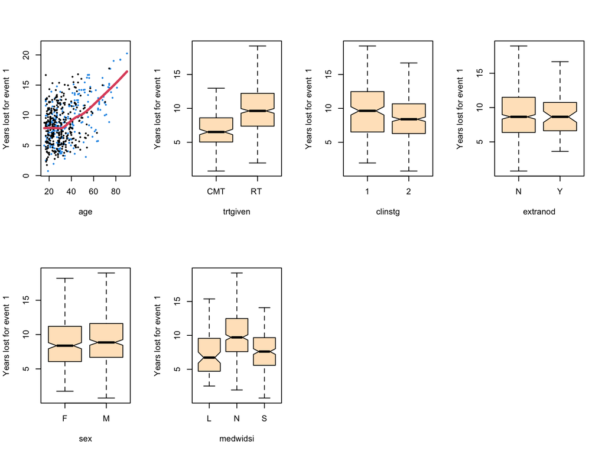

```r
plot.variable(rsf.lrCR, target = 1,
              surv.type = "years.lost",
              sorted = TRUE)
```

In-bag and out-of-bag estimates of the cause-specific cumulative hazard function and the CIF. Below, we show out-of-bag-estimates for the event of interest (relapse). `csh.oob` and `cif.oob` are array that contains in the rows estimates corresponding to the $692$ subjects and in the columns the $136$ unique times.

```r
obsv.times <- rsf.lrCR$time.interest  # unique observed event times

#out-of-bag cause-specific cumulative hazard
csh.oob <- rsf.lrCR$chf.oob[,,1]  # selects event type 1

#out-of-bag CIF
cif.oob <- rsf.lrCR$cif.oob[,,1]  # selects event type 1
```

In order to do variable selection, as variable importance measure for the event of interest is shown below. The higher the value, the better. Negative values indicate no predictive ability.

```r
rsf.lrCR$importance[,1]
```

```
#>          age          sex     trtgiven     medwidsi     extranod      clinstg
#>  0.016969667 -0.002039459  0.015975435 -0.004734901 -0.001124025  0.002350809
```

In order to obtain predictions in the test set, we employ `predict()` function as shown below. A summary of the object is shown with the function `print()`

```r
test.lrCR <- predict(rsf.lrCR,
                   newdata = hd_test,
                   importance = "permute"  #VIM can also be obtained at this stage
                   )
print(test.lrCR)
```

```
#>   Sample size of test (predict) data: 173
#>                 Number of grow trees: 100
#>   Average no. of grow terminal nodes: 48.37
#>          Total no. of grow variables: 6
#>        Resampling used to grow trees: swr
#>     Resample size used to grow trees: 692
#>                             Analysis: RSF
#>                               Family: surv-CR
#>          Requested performance error: 0.38690476, 0.23518072
```

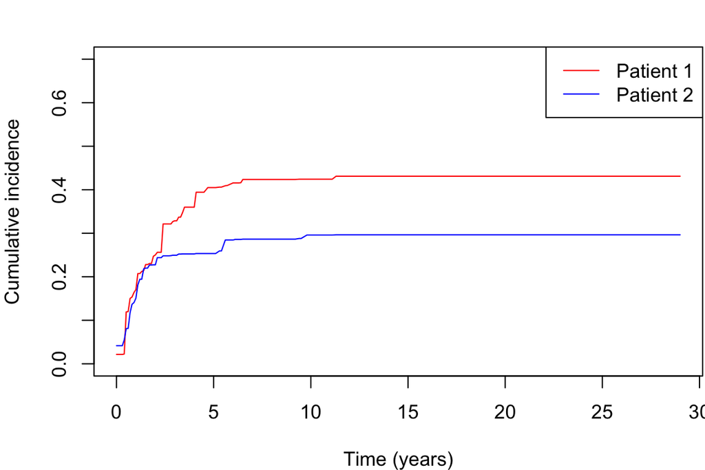

```r
CIF.hat <- rsf.lrCR$cif[,,1]  # select event of interest k=1

par(mar = c(4, 4, 2, 0.1))

plot(test.lrCR$time.interest,
     CIF.hat[1,],
     type = "l",
     col = "red",
     ylim = c(0, 0.7),
     xlab = "Time (years)",
     ylab = "Cumulative incidence")
lines(test.lrCR$time.interest,  CIF.hat[2,], col="blue")
legend("topright", legend = c("Patient 1", "Patient 2"),
       lty = c(1,1), col = c("red", "blue"))
```

Predicted CIF at $t=5$ for the first 5 subjects in the test set are shown:

```r
test.lrCR$cif[1:5,obsv.times==5,1]
```

```
#> [1] 0.2471439 0.4264480 0.3513243 0.1933283 0.3215940
```

# References

Ishwaran, Hemant, Thomas A. Gerds, Bryan M. Lau, Min Lu, and Udaya B. Kogalur. 2021. “randomForestSRC: Competing Risks Vignette.” http://randomforestsrc.org/articles/competing.html.

Pintilie, Melania. 2006. *Competing Risks: A Practical Perspective*. John Wiley & Sons.